# Uncovering the role of conductive materials on anaerobic digestion

## Assay:

Peptide mapping by nanoLC-MS using SciexTripleTOF 6600 mass spectrometer.

## Database search:

Generated mass spectra were processed using Protein Pilot Software v. 5.0 (Sciex) for protein identification. The search was performed against the UniProt (reviewed and unreviewed) protein sequences for Methanobacterium formicicum. Peptide identification was considered with >95% confidence.

## List of samples for proteomics analysis

- **Amostra 1 (CS1)** – Cultura pura Methanobacterium formicicum (controlo sem material), na fase inicial da produção de metano ("initial methane production" – IMP)
- **Amostra 2 (CS2)** – Cultura pura M. formicicum (controlo sem material), na fase exponencial da produção de metano ("exponential methane production" – EMP)
- **Amostra 3 (CS3)** – Cultura pura M. formicicum (controlo sem material), na fase final da produção de metano ("End of methane production" – END)
- **Amostra 4 (CS4)** – Cultura pura M. formicicum + 0.5 g/L activated carbon (AC), na fase inicial da produção de metano (IMP)
- **Amostra 5 (CS5)** – Cultura pura M. formicicum + 0.5 g/L AC, na fase exponencial da produção de metano (EMP)
- **Amostra 6 (CS6)** – Cultura pura M. formicicum + 0.5 g/L AC, na fase final da produção de metano (END)

| Descrição da amostra | Fase de amostragem | Concentração/(ug/ul) | Volume carregado no gel SDS)/ul | proteína por poço (1 fração)/ug | Proteína em 2 frações de amostra / ug |
| --- | --- | --- | --- | --- | --- |
| M. formicicum (control) | Amostra 1) IMP | 0.215 | 16.2 | 3.5 | 7.0 |
| M. formicicum (control) | Amostra 2) EMP | 0.709 | 16.2 | 11.5 | 23.0 |
| M. formicicum (control) | Amostra 3) End (*) | 0.12 | 16.2 | 1.9 | 3.9 |
| M. formicicum + 0.5 g/L AC | Amostra 4) IMP | 0.232 | 16.2 | 3.8 | 7.5 |
| M. formicicum + 0.5 g/L AC | Amostra 5) EMP(*) | 0.109 | 16.2 | 1.8 | 3.5 |
| M. formicicum + 0.5 g/L AC | Amostra 6) End | 0.373 | 16.2 | 6.0 | 12.1 |

(*) As concentrações das amostras 3 e 5 são medições antes da concentração da amostra; não temos o valor após concentração (não foi possível quantificar).

## From WIFF to RAW:

First, had to download the [ZIP archive](https://github.com/mzdb/pwiz-mzdb/releases/download/0.9.10/raw2mzDB_0.9.10_build20170802.zip) and unzip it. Then, had to convert WIFF to mzDB, through the CMD.

```
D:
cd "Documentos\Trabalho\7. 1 Outubro 2019 - 30 Setembro 2023\Cursos_GTPB"
"raw2mzDB_0.9.10_build20170802/raw2mzDB.exe" -i formicicum_proteomics/wiff/CS1_9uL.wiff -o formicicum_proteomics/wiff/CS1_9uL.wiff.mzDB
"raw2mzDB_0.9.10_build20170802/raw2mzDB.exe" -i formicicum_proteomics/wiff/CS2_4uL.wiff -o formicicum_proteomics/wiff/CS2_4uL.wiff.mzDB
"raw2mzDB_0.9.10_build20170802/raw2mzDB.exe" -i formicicum_proteomics/wiff/CS3_9uL.wiff -o formicicum_proteomics/wiff/CS3_9uL.wiff.mzDB
"raw2mzDB_0.9.10_build20170802/raw2mzDB.exe" -i formicicum_proteomics/wiff/CS4_9uL.wiff -o formicicum_proteomics/wiff/CS4_9uL.wiff.mzDB
"raw2mzDB_0.9.10_build20170802/raw2mzDB.exe" -i formicicum_proteomics/wiff/CS5_9uL.wiff -o formicicum_proteomics/wiff/CS5_9uL.wiff.mzDB
"raw2mzDB_0.9.10_build20170802/raw2mzDB.exe" -i formicicum_proteomics/wiff/CS6_9uL.wiff -o formicicum_proteomics/wiff/CS6_9uL.wiff.mzDB
```

After running CS1_9uL, got this

```
I1120 10:21:50.065062 16612 mzdb_writer.hpp:232] AB Sciex metadata extractor created
I1120 10:21:50.065062 16612 mzdb_writer.cpp:406] updating dataProcessing...
I1120 10:21:50.065062 16612 mzdb_writer.cpp:1051] DDA / DIA test
I1120 10:25:29.943912 16612 mzdb_writer.cpp:1056] DDA Mode detected
I1120 10:25:29.943912 16612 raw2mzDB.cpp:611]

************ Summary of the parameters ************

Treating file: formicicum_proteomics/wiff/CS1_9uL.wiff (DDA ABI WIFF format)
MS 1    Selected Mode: FITTED
MS 2    Selected Mode: CENTROID

Bounding box dimensions:
MS 1    m/z: 5 Da, retention time: 15sec
MS n    m/z: 10000 Da, retention time: 0sec

I1120 10:25:29.943912 16612 mzdb_writer.hpp:352]
I1120 10:25:29.943912 16612 mzdb_writer.hpp:353] SQLITE VERSION: 3.8.9
I1120 10:25:29.943912 16612 mzdb_writer.hpp:354] ProteoWizard release: 3.0.7320 (2015-3-18)
I1120 10:25:29.943912 16612 mzdb_writer.hpp:355] ProteoWizard MSData: 3.0.7303 (2015-3-13)
I1120 10:25:29.943912 16612 mzdb_writer.cpp:97] Settings SQLite pragmas...
I1120 10:25:29.943912 16612 mzdb_writer.cpp:121] Create database tables...
I1120 10:25:29.943912 16612 mzdb_writer.cpp:695] Pwiz Sample was empty. Filling it...
I1120 10:25:29.943912 16612 mzdb_writer.cpp:743] use default source file
I1120 10:25:30.037648 16612 mzdb_writer.hpp:390] SpectrumList size: 95067
I1120 10:25:30.037648 16612 mzdb_writer.hpp:412] #detected core(s): 4
I1120 10:25:30.037648 16612 mzdb_writer.hpp:465] ABI spectrumList
I1120 10:25:30.037648 16612 mzdb_writer.hpp:473] DDA producer/consumer
[==================================================] 100%
I1120 10:56:46.579810 16612 mzdb_writer.hpp:536] Creating permanent spectrum table
I1120 10:57:10.472071 16612 mzdb_writer.cpp:368] Creates indexes...
I1120 10:57:45.062134 16612 spectrum_inserter.h:599]

************ Summary of the conversion ************

Created file: formicicum_proteomics/wiff/CS1_9uL.wiff.mzDB
MS      Input           Output          Nb spectra
MS1     PROFILE         FITTED          5975
MS2     PROFILE         CENTROID        89092


I1120 10:57:45.077716 16612 raw2mzDB.cpp:635] Checking run slices numbers
I1120 10:57:45.077716 16612 mzdb_writer.cpp:1013] Detected problem in run slice number...fixing it
I1120 10:57:45.233960 16612 raw2mzDB.cpp:652] Elapsed Time: 1935.29 sec
```

## Quality check

First, we have to import the data in database (mzDB) format.

```r
library(RSQLite)
library(rmzdb)

sample1_9 <- "wiff/CS1_9uL.wiff.mzDB"
sample2_4 <- "wiff/CS2_4uL.wiff.mzDB"
sample3_9 <- "wiff/CS3_9uL.wiff.mzDB"
sample4_9 <- "wiff/CS4_9uL.wiff.mzDB"
sample5_9 <- "wiff/CS5_9uL.wiff.mzDB"
sample6_9 <- "wiff/CS6_9uL.wiff.mzDB"

sqlite_sample1_9 <- dbConnect(RSQLite::SQLite(), sample1_9)
sqlite_sample2_4 <- dbConnect(RSQLite::SQLite(), sample2_4)
sqlite_sample3_9 <- dbConnect(RSQLite::SQLite(), sample3_9)
sqlite_sample4_9 <- dbConnect(RSQLite::SQLite(), sample4_9)
sqlite_sample5_9 <- dbConnect(RSQLite::SQLite(), sample5_9)
sqlite_sample6_9 <- dbConnect(RSQLite::SQLite(), sample6_9)
```

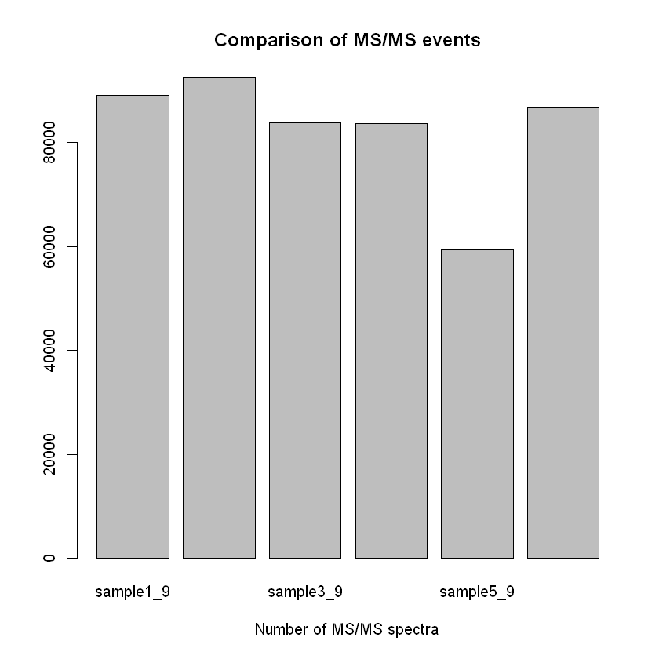

```r
sample1_9_ms2_count <- dbGetQuery(sqlite_sample1_9, "SELECT count(*) as n FROM spectrum WHERE ms_level = 2")
sample2_4_ms2_count <- dbGetQuery(sqlite_sample2_4, "SELECT count(*) as n FROM spectrum WHERE ms_level = 2")
sample3_9_ms2_count <- dbGetQuery(sqlite_sample3_9, "SELECT count(*) as n FROM spectrum WHERE ms_level = 2")
sample4_9_ms2_count <- dbGetQuery(sqlite_sample4_9, "SELECT count(*) as n FROM spectrum WHERE ms_level = 2")
sample5_9_ms2_count <- dbGetQuery(sqlite_sample5_9, "SELECT count(*) as n FROM spectrum WHERE ms_level = 2")
sample6_9_ms2_count <- dbGetQuery(sqlite_sample6_9, "SELECT count(*) as n FROM spectrum WHERE ms_level = 2")

ms2_count <- c(sample1_9_ms2_count$n, sample2_4_ms2_count$n, sample3_9_ms2_count$n, sample4_9_ms2_count$n, sample5_9_ms2_count$n, sample6_9_ms2_count$n)
barplot(ms2_count, main="Comparison of MS/MS events",  xlab="Number of MS/MS spectra",
        names.arg=c("sample1_9", "sample2_4", "sample3_9", "sample4_9", "sample5_9", "sample6_9")
       )
```

### MS/MS events at the MS2 level

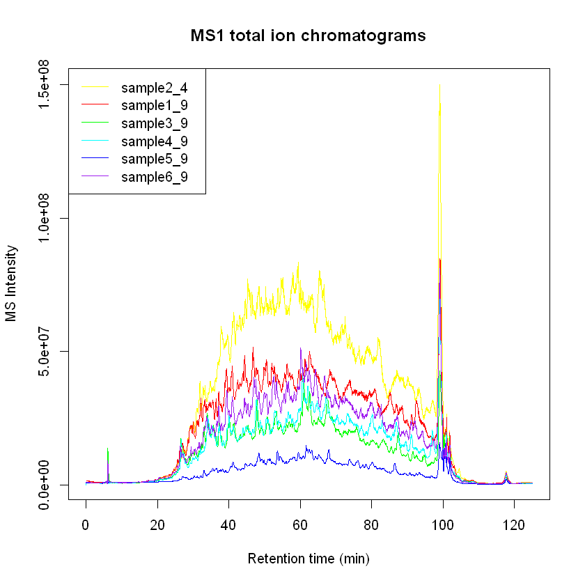

```r
sample1_9_ms1_tic <- dbGetQuery(sqlite_sample1_9, "SELECT (time / 60) as rt, tic as intensity FROM spectrum WHERE ms_level = 1")
sample2_4_ms1_tic <- dbGetQuery(sqlite_sample2_4, "SELECT (time / 60) as rt, tic as intensity FROM spectrum WHERE ms_level = 1")
sample3_9_ms1_tic <- dbGetQuery(sqlite_sample3_9, "SELECT (time / 60) as rt, tic as intensity FROM spectrum WHERE ms_level = 1")
sample4_9_ms1_tic <- dbGetQuery(sqlite_sample4_9, "SELECT (time / 60) as rt, tic as intensity FROM spectrum WHERE ms_level = 1")
sample5_9_ms1_tic <- dbGetQuery(sqlite_sample5_9, "SELECT (time / 60) as rt, tic as intensity FROM spectrum WHERE ms_level = 1")
sample6_9_ms1_tic <- dbGetQuery(sqlite_sample6_9, "SELECT (time / 60) as rt, tic as intensity FROM spectrum WHERE ms_level = 1")

plot(sample2_4_ms1_tic$rt,sample2_4_ms1_tic$intensity, type="l", col="yellow", lwd=1, xlab="Retention time (min)", ylab="MS Intensity", main = "MS1 total ion chromatograms")
lines(sample1_9_ms1_tic$rt,sample1_9_ms1_tic$intensity, type="l", col="red", lwd=1)
lines(sample3_9_ms1_tic$rt,sample3_9_ms1_tic$intensity, type="l", col="green", lwd=1)
lines(sample4_9_ms1_tic$rt,sample4_9_ms1_tic$intensity, type="l", col="cyan", lwd=1)
lines(sample5_9_ms1_tic$rt,sample5_9_ms1_tic$intensity, type="l", col="blue", lwd=1)
lines(sample6_9_ms1_tic$rt,sample6_9_ms1_tic$intensity, type="l", col="purple", lwd=1)
legend("topleft",c("sample2_4", "sample1_9", "sample3_9", "sample4_9", "sample5_9", "sample6_9"), lwd=c(1,1), col=c("yellow", "red", "green", "cyan", "blue", "purple"))
```

### Total ion chromatogram at the MS1 level

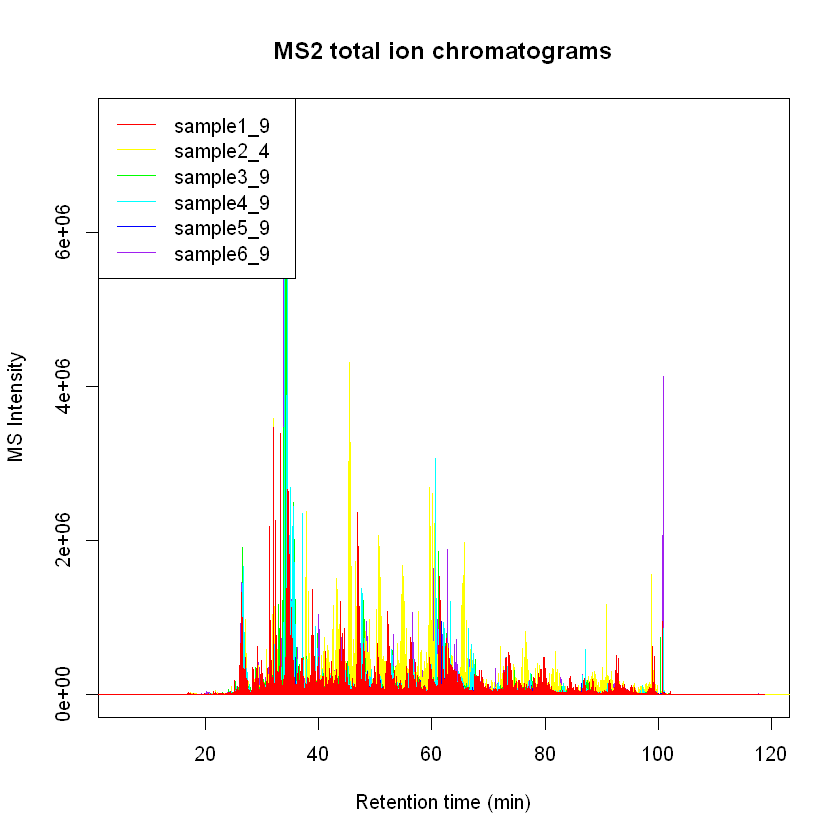

```r
sample1_9_ms2_tic <- dbGetQuery(sqlite_sample1_9, "SELECT (time / 60) as rt, tic as intensity FROM spectrum WHERE ms_level = 2")
sample2_4_ms2_tic <- dbGetQuery(sqlite_sample2_4, "SELECT (time / 60) as rt, tic as intensity FROM spectrum WHERE ms_level = 2")
sample3_9_ms2_tic <- dbGetQuery(sqlite_sample3_9, "SELECT (time / 60) as rt, tic as intensity FROM spectrum WHERE ms_level = 2")
sample4_9_ms2_tic <- dbGetQuery(sqlite_sample4_9, "SELECT (time / 60) as rt, tic as intensity FROM spectrum WHERE ms_level = 2")
sample5_9_ms2_tic <- dbGetQuery(sqlite_sample5_9, "SELECT (time / 60) as rt, tic as intensity FROM spectrum WHERE ms_level = 2")
sample6_9_ms2_tic <- dbGetQuery(sqlite_sample6_9, "SELECT (time / 60) as rt, tic as intensity FROM spectrum WHERE ms_level = 2")

plot(sample6_9_ms2_tic$rt,sample6_9_ms2_tic$intensity, type="l", col="purple", lwd=1, xlab="Retention time (min)", ylab="MS Intensity", main = "MS2 total ion chromatograms")
lines(sample2_4_ms2_tic$rt,sample2_4_ms2_tic$intensity, type="l", col="yellow", lwd=1)
lines(sample3_9_ms2_tic$rt,sample3_9_ms2_tic$intensity, type="l", col="green", lwd=1)
lines(sample4_9_ms2_tic$rt,sample4_9_ms2_tic$intensity, type="l", col="cyan", lwd=1)
lines(sample5_9_ms2_tic$rt,sample5_9_ms2_tic$intensity, type="l", col="blue", lwd=1)
lines(sample1_9_ms2_tic$rt,sample1_9_ms2_tic$intensity, type="l", col="red", lwd=1)
legend("topleft",c("sample1_9", "sample2_4", "sample3_9", "sample4_9", "sample5_9", "sample6_9"), lwd=c(1,1), col=c("red", "yellow", "green", "cyan", "blue", "purple"))
```

### Total ion chromatogram at the MS2 level

Now using David's rmzdb library.

```r
mzdb_sample1_9 <- new(MzDb, sample1_9)
mzdb_sample2_4 <- new(MzDb, sample2_4)
mzdb_sample3_9 <- new(MzDb, sample3_9)
mzdb_sample4_9 <- new(MzDb, sample4_9)
mzdb_sample5_9 <- new(MzDb, sample5_9)
mzdb_sample6_9 <- new(MzDb, sample6_9)

# This are the m/z values of the cytochrome peptide ions
KYPGTK_mz <- 403.7422
KIFVQK_mz <- 381.7473
KTGQAPGFSYTDANK_mz_z2 <- 792.8863
KTGQAPGFSYTDANK_mz_z3 <- 528.9266
KGEREDLIAYLK_mz <- 717.9012
TGPNLHGLFGR_mz_z2 <- 584.8147
TGPNLHGLFGR_mz_z3 <- 390.2122
MIFAGIK_mz <- 390.2278

# We have to create extractors for the samples
chromx_sample1_9 <- new (MzDbExtractor, mzdb_sample1_9)
chromx_sample2_4 <- new (MzDbExtractor, mzdb_sample2_4)
chromx_sample3_9 <- new (MzDbExtractor, mzdb_sample3_9)
chromx_sample4_9 <- new (MzDbExtractor, mzdb_sample4_9)
chromx_sample5_9 <- new (MzDbExtractor, mzdb_sample5_9)
chromx_sample6_9 <- new (MzDbExtractor, mzdb_sample6_9)
```

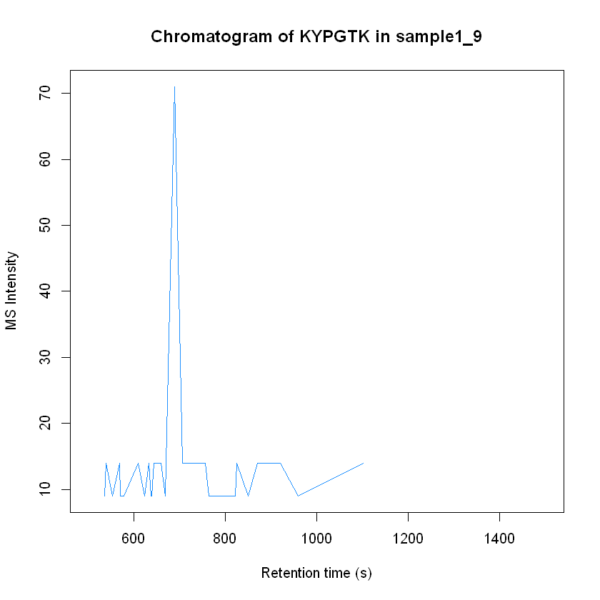

```r
KYPGTK_sample1_9_chrom <- chromx_sample1_9$get_xic(KYPGTK_mz,0.001,500,1500,1,-1)

plot(KYPGTK_sample1_9_chrom[,1],KYPGTK_sample1_9_chrom[,2], type="l", col="dodgerblue", lwd=1, xlab="Retention time (s)", ylab="MS Intensity",xlim=c(500,1500), main="Chromatogram of KYPGTK in sample1_9")
```

### Cytochrome precursor selected ion current profile

This intensity seems to be just noise. While the course samples went to 3e7 of intensity, here we get maximum 70. This type of analysis, however, seems to allow for querying for exact peptides of interest, or at least their m/Zs, since many others may share the same m/Z.

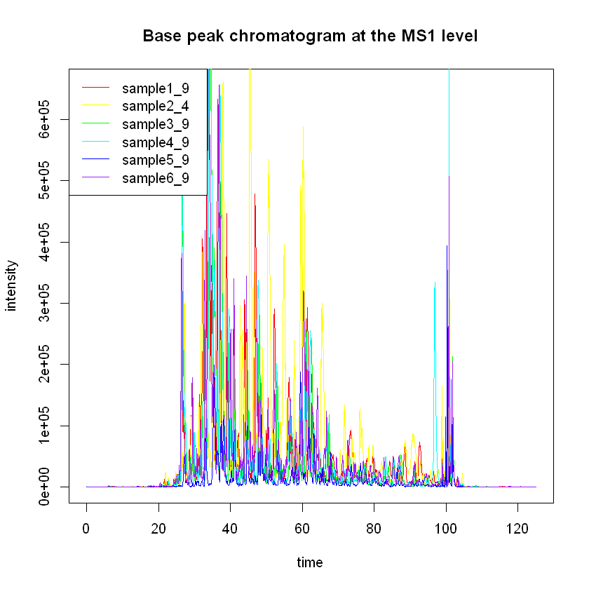

```r
sample1_9_ms1_bpc <- dbGetQuery(sqlite_sample1_9, "SELECT (time/60) as t,base_peak_intensity as intensity FROM spectrum WHERE ms_level = 1")
sample2_4_ms1_bpc <- dbGetQuery(sqlite_sample2_4, "SELECT (time/60) as t,base_peak_intensity as intensity FROM spectrum WHERE ms_level = 1")
sample3_9_ms1_bpc <- dbGetQuery(sqlite_sample3_9, "SELECT (time/60) as t,base_peak_intensity as intensity FROM spectrum WHERE ms_level = 1")
sample4_9_ms1_bpc <- dbGetQuery(sqlite_sample4_9, "SELECT (time/60) as t,base_peak_intensity as intensity FROM spectrum WHERE ms_level = 1")
sample5_9_ms1_bpc <- dbGetQuery(sqlite_sample5_9, "SELECT (time/60) as t,base_peak_intensity as intensity FROM spectrum WHERE ms_level = 1")
sample6_9_ms1_bpc <- dbGetQuery(sqlite_sample6_9, "SELECT (time/60) as t,base_peak_intensity as intensity FROM spectrum WHERE ms_level = 1")

plot(sample1_9_ms1_bpc$t,sample1_9_ms1_bpc$intensity, type="l", col="red", lwd=1, xlab="time", ylab="intensity", main="Base peak chromatogram at the MS1 level")
lines(sample2_4_ms1_bpc$t,sample2_4_ms1_bpc$intensity, type="l", col="yellow", lwd=1)
lines(sample3_9_ms1_bpc$t,sample3_9_ms1_bpc$intensity, type="l", col="green", lwd=1)
lines(sample4_9_ms1_bpc$t,sample4_9_ms1_bpc$intensity, type="l", col="cyan", lwd=1)
lines(sample5_9_ms1_bpc$t,sample5_9_ms1_bpc$intensity, type="l", col="blue", lwd=1)
lines(sample6_9_ms1_bpc$t,sample6_9_ms1_bpc$intensity, type="l", col="purple", lwd=1)
legend("topleft",c("sample1_9", "sample2_4", "sample3_9", "sample4_9", "sample5_9", "sample6_9"), lwd=c(1,1), col=c("red", "yellow", "green", "cyan", "blue", "purple"))
```

### Base peak chromatogram at the MS1 level

Difference between total ion chromatogram, base peak chromatogram and selected ion current profile: https://www.chromforum.org/viewtopic.php?t=1952

This plot represents the intensity of the most abundant species at each point in time. It should generally be less noisy. This plot, however, seems very noisy, while some peaks do stand out. Now, lets see the major peaks for each sample - this are the precursors with the highest intensity on each sample.

```r
sample1_9_top10_highest_precs <- dbGetQuery(sqlite_sample1_9, "SELECT main_precursor_mz as mz, (time / 60) as rt FROM spectrum WHERE ms_level = 2 ORDER BY tic DESC LIMIT 10")
sample2_4_top10_highest_precs <- dbGetQuery(sqlite_sample2_4, "SELECT main_precursor_mz as mz, (time / 60) as rt FROM spectrum WHERE ms_level = 2 ORDER BY tic DESC LIMIT 10")
sample3_9_top10_highest_precs <- dbGetQuery(sqlite_sample3_9, "SELECT main_precursor_mz as mz, (time / 60) as rt FROM spectrum WHERE ms_level = 2 ORDER BY tic DESC LIMIT 10")
sample4_9_top10_highest_precs <- dbGetQuery(sqlite_sample4_9, "SELECT main_precursor_mz as mz, (time / 60) as rt FROM spectrum WHERE ms_level = 2 ORDER BY tic DESC LIMIT 10")
sample5_9_top10_highest_precs <- dbGetQuery(sqlite_sample5_9, "SELECT main_precursor_mz as mz, (time / 60) as rt FROM spectrum WHERE ms_level = 2 ORDER BY tic DESC LIMIT 10")
sample6_9_top10_highest_precs <- dbGetQuery(sqlite_sample6_9, "SELECT main_precursor_mz as mz, (time / 60) as rt FROM spectrum WHERE ms_level = 2 ORDER BY tic DESC LIMIT 10")
cbind(sample1_9_top10_highest_precs, sample2_4_top10_highest_precs, sample3_9_top10_highest_precs, sample4_9_top10_highest_precs, sample5_9_top10_highest_precs, sample6_9_top10_highest_precs)
```

A data.frame: 10 × 12

| mz <dbl> | rt <dbl> | mz <dbl> | rt <dbl> | mz <dbl> | rt <dbl> | mz <dbl> | rt <dbl> | mz <dbl> | rt <dbl> | mz <dbl> | rt <dbl> |
| --- | --- | --- | --- | --- | --- | --- | --- | --- | --- | --- | --- |
| 517.8486 | 32.13892 | 550.8146 | 45.46430 | 423.2255 | 34.14753 | 423.0355 | 34.06187 | 737.9332 | 61.72780 | 423.2068 | 33.85297 |
| 423.1617 | 33.27150 | 517.8496 | 32.10455 | 423.0326 | 34.33150 | 423.0941 | 34.52316 | 423.1904 | 35.93142 | 423.1948 | 34.06928 |
| 450.2646 | 34.53658 | 550.8160 | 45.67095 | 423.5812 | 34.45433 | 423.6266 | 34.01653 | 737.6974 | 61.68948 | 408.7025 | 100.81003 |
| 450.2654 | 34.74490 | 550.8114 | 45.25932 | 423.4370 | 33.90820 | 423.5615 | 34.33187 | 423.2138 | 35.09047 | 423.2217 | 34.44160 |
| 550.8145 | 46.83607 | 551.8079 | 59.55665 | 450.2638 | 35.55358 | 738.2827 | 60.72887 | 550.8155 | 48.62070 | 586.0657 | 62.74513 |
| 518.1167 | 32.35325 | 659.3683 | 60.19445 | 450.2639 | 35.34293 | 423.1846 | 35.10945 | 550.8133 | 48.41905 | 737.7037 | 60.25482 |
| 428.6687 | 31.37863 | 605.2653 | 37.95315 | 450.2635 | 35.75790 | 450.2632 | 35.61643 | 450.2633 | 36.48271 | 737.7066 | 60.45747 |
| 550.8151 | 47.04438 | 659.3686 | 60.40910 | 523.2785 | 26.52853 | 436.8825 | 37.21682 | 659.3661 | 63.21954 | 523.2822 | 26.46115 |
| 450.2674 | 34.95555 | 551.8087 | 59.76613 | 738.5810 | 61.12700 | 450.2613 | 35.40578 | 428.5308 | 32.85747 | 450.2649 | 35.28403 |
| 517.5934 | 32.39657 | 683.8874 | 50.53178 | 422.6867 | 34.66565 | 423.5947 | 34.82515 | 450.2646 | 36.27105 | 450.2639 | 35.07438 |

### Highest intensity precursors

I searched for the most abundant precursors:

- Sample 1_9: 550.815 is only reported [here](https://www.mcponline.org/content/mcprot/suppl/2010/07/19/M900641-MCP200.DC1/Supplementary_Table_S2.pdf).
- Sample 2_4: Also reports the 550.815 several times. Did not find the 683.887 nor 659.368
- Sample 3_9: 423.033 and similars seem to be [3-(Methylsulfinyl)propyl glucosinolate](https://pubchem.ncbi.nlm.nih.gov/compound/15560239); 738.581 appears as being precursor of "MORC2_HUMAN MORC family CW-type zinc finger protein 2" of pancreatic stellate cells, in a [supplementary information](http://links.lww.com/MPA/A573) and [another](http://www.helsinki.fi/biochipcenter/Jarvinen_Supplement/OLIGO/16011521022524.txt).
- Sample 4_9: also has the 423.033 or similar; 738.2827 as been reported as C35H49ClN3O10S (M + H)+ [here](https://pubs.acs.org/doi/full/10.1021/jm060319f?src=recsys).
- Sample 5_9: 737s and 423s appear a lot.
- Sample 6_9: ditto. May have to find the right m/Z for these species.